# Video_Games_Case_Study

Ralph Gracia

2023-11-10

## Setting Up My Environment

Before starting any work with the data, I made sure I had the necessary packages installed and ready to go.

```r
install.packages("tidyverse")
library(tidyverse)
install.packages("rmarkdown")
library(rmarkdown)
```

## Preparing The Data

I begun my work by taking a quick look at how the data is structured. Here we can get a better understanding of the variables and values stored within the data.

To view the source of my data click here [link](https://www.kaggle.com/datasets/ibriiee/video-games-sales-dataset-2022-updated-extra-feat)

```r
video_games <- read.csv("Video_Games.csv")
head(video_games)
```

```
##                       Name Platform Year_of_Release        Genre Publisher
## 1               Wii Sports      Wii            2006       Sports  Nintendo
## 2        Super Mario Bros.      NES            1985     Platform  Nintendo
## 3           Mario Kart Wii      Wii            2008       Racing  Nintendo
## 4        Wii Sports Resort      Wii            2009       Sports  Nintendo
## 5 Pokemon Red/Pokemon Blue       GB            1996 Role-Playing  Nintendo
## 6                   Tetris       GB            1989       Puzzle  Nintendo
##   NA_Sales EU_Sales JP_Sales Other_Sales Global_Sales Critic_Score Critic_Count
## 1    41.36    28.96     3.77        8.45        82.53           76           51
## 2    29.08     3.58     6.81        0.77        40.24           NA           NA
## 3    15.68    12.76     3.79        3.29        35.52           82           73
## 4    15.61    10.93     3.28        2.95        32.77           80           73
## 5    11.27     8.89    10.22        1.00        31.37           NA           NA
## 6    23.20     2.26     4.22        0.58        30.26           NA           NA
##   User_Score User_Count Developer Rating
## 1          8        322  Nintendo      E
## 2                    NA
## 3        8.3        709  Nintendo      E
## 4          8        192  Nintendo      E
## 5                    NA
## 6                    NA
```

## Cleaning The Data

For this case study, my goal is to find information relevant to how games have performed from 2008 to early 2017 and what the most popular genres were. In order to achieve that, the first thing I needed to address was rows that had didn’t have a release year available in this dataset. I ultimately came to the conclusion that filtering out these rows wouldn’t affect the overall results.

```r
last_15_years <- video_games %>% filter(Year_of_Release >= 2008) %>%
  arrange(-Global_Sales)
head(last_15_years)
```

```
##                        Name Platform Year_of_Release    Genre
## 1            Mario Kart Wii      Wii            2008   Racing
## 2         Wii Sports Resort      Wii            2009   Sports
## 3 New Super Mario Bros. Wii      Wii            2009 Platform
## 4        Kinect Adventures!     X360            2010     Misc
## 5              Wii Fit Plus      Wii            2009   Sports
## 6        Grand Theft Auto V      PS3            2013   Action
##                Publisher NA_Sales EU_Sales JP_Sales Other_Sales Global_Sales
## 1               Nintendo    15.68    12.76     3.79        3.29        35.52
## 2               Nintendo    15.61    10.93     3.28        2.95        32.77
## 3               Nintendo    14.44     6.94     4.70        2.24        28.32
## 4 Microsoft Game Studios    15.00     4.89     0.24        1.69        21.81
## 5               Nintendo     9.01     8.49     2.53        1.77        21.79
## 6   Take-Two Interactive     7.02     9.09     0.98        3.96        21.04
##   Critic_Score Critic_Count User_Score User_Count           Developer Rating
## 1           82           73        8.3        709            Nintendo      E
## 2           80           73          8        192            Nintendo      E
## 3           87           80        8.4        594            Nintendo      E
## 4           61           45        6.3        106 Good Science Studio      E
## 5           80           33        7.4         52            Nintendo      E
## 6           97           50        8.2       3994      Rockstar North      M
```

The next step was to create new data frames for each console and see how well each console’s games have performed in each region since from 2008-2017.

#### Playstation

```r
ps_games <- last_15_years %>% filter(Platform =="PS" | Platform =="PS2" | Platform =="PS3" | Platform =="PSV" | Platform =="PSP"| Platform =="PS4") %>%
  filter(!is.na(Year_of_Release)) %>% arrange(-Global_Sales)
head(ps_games)
```

```
##                             Name Platform Year_of_Release   Genre
## 1             Grand Theft Auto V      PS3            2013  Action
## 2      Call of Duty: Black Ops 3      PS4            2015 Shooter
## 3     Call of Duty: Black Ops II      PS3            2012 Shooter
## 4 Call of Duty: Modern Warfare 3      PS3            2011 Shooter
## 5        Call of Duty: Black Ops      PS3            2010 Shooter
## 6             Grand Theft Auto V      PS4            2014  Action
##              Publisher NA_Sales EU_Sales JP_Sales Other_Sales Global_Sales
## 1 Take-Two Interactive     7.02     9.09     0.98        3.96        21.04
## 2           Activision     6.03     5.86     0.36        2.38        14.63
## 3           Activision     4.99     5.73     0.65        2.42        13.79
## 4           Activision     5.54     5.73     0.49        1.57        13.32
## 5           Activision     5.99     4.37     0.48        1.79        12.63
## 6 Take-Two Interactive     3.96     6.31     0.38        1.97        12.61
##   Critic_Score Critic_Count User_Score User_Count
## 1           97           50        8.2       3994
## 2           NA           NA                    NA
## 3           83           21        5.3        922
## 4           88           39        3.2       5234
## 5           88           58        6.4       1094
## 6           97           66        8.3       2899
##                           Developer Rating
## 1                    Rockstar North      M
## 2
## 3                          Treyarch      M
## 4 Infinity Ward, Sledgehammer Games      M
## 5                          Treyarch      M
## 6                    Rockstar North      M
```

#### Xbox

```r
xbox_games <- last_15_years %>% filter(Platform == "XB" | Platform == "X360"  | Platform == "XOne") %>%
  filter(!is.na(Year_of_Release)) %>% arrange(-Global_Sales)
head(xbox_games)
```

```
##                             Name Platform Year_of_Release   Genre
## 1             Kinect Adventures!     X360            2010    Misc
## 2             Grand Theft Auto V     X360            2013  Action
## 3 Call of Duty: Modern Warfare 3     X360            2011 Shooter
## 4        Call of Duty: Black Ops     X360            2010 Shooter
## 5     Call of Duty: Black Ops II     X360            2012 Shooter
## 6 Call of Duty: Modern Warfare 2     X360            2009 Shooter
##                Publisher NA_Sales EU_Sales JP_Sales Other_Sales Global_Sales
## 1 Microsoft Game Studios    15.00     4.89     0.24        1.69        21.81
## 2   Take-Two Interactive     9.66     5.14     0.06        1.41        16.27
## 3             Activision     9.04     4.24     0.13        1.32        14.73
## 4             Activision     9.70     3.68     0.11        1.13        14.61
## 5             Activision     8.25     4.24     0.07        1.12        13.67
## 6             Activision     8.52     3.59     0.08        1.28        13.47
##   Critic_Score Critic_Count User_Score User_Count
## 1           61           45        6.3        106
## 2           97           58        8.1       3711
## 3           88           81        3.4       8713
## 4           87           89        6.3       1454
## 5           83           73        4.8       2256
## 6           94          100        6.3       2698
##                           Developer Rating
## 1               Good Science Studio      E
## 2                    Rockstar North      M
## 3 Infinity Ward, Sledgehammer Games      M
## 4                          Treyarch      M
## 5                          Treyarch      M
## 6                     Infinity Ward      M
```

#### Nintendo

```r
nintendo_games <- last_15_years %>% filter(Platform =="DS" | Platform =="3DS" | Platform =="Wii" | Platform =="WiiU") %>%
  filter(!is.na(Year_of_Release)) %>% arrange(-Global_Sales)
head(nintendo_games)
```

```
##                          Name Platform Year_of_Release        Genre Publisher
## 1              Mario Kart Wii      Wii            2008       Racing  Nintendo
## 2           Wii Sports Resort      Wii            2009       Sports  Nintendo
## 3   New Super Mario Bros. Wii      Wii            2009     Platform  Nintendo
## 4                Wii Fit Plus      Wii            2009       Sports  Nintendo
## 5 Pokemon Black/Pokemon White       DS            2010 Role-Playing  Nintendo
## 6         Pokemon X/Pokemon Y      3DS            2013 Role-Playing  Nintendo
##   NA_Sales EU_Sales JP_Sales Other_Sales Global_Sales Critic_Score Critic_Count
## 1    15.68    12.76     3.79        3.29        35.52           82           73
## 2    15.61    10.93     3.28        2.95        32.77           80           73
## 3    14.44     6.94     4.70        2.24        28.32           87           80
## 4     9.01     8.49     2.53        1.77        21.79           80           33
## 5     5.51     3.17     5.65        0.80        15.14           NA           NA
## 6     5.28     4.19     4.35        0.78        14.60           NA           NA
##   User_Score User_Count Developer Rating
## 1        8.3        709  Nintendo      E
## 2          8        192  Nintendo      E
## 3        8.4        594  Nintendo      E
## 4        7.4         52  Nintendo      E
## 5                    NA
## 6                    NA
```

## Visualizing Trends

My original objective is to review the data and learn what the top genres of games were on each console based on their top 100 games. After analyzing the new data frames, I used ggplot to visualize my findings.

### Top Playstation Genres (Million USD)

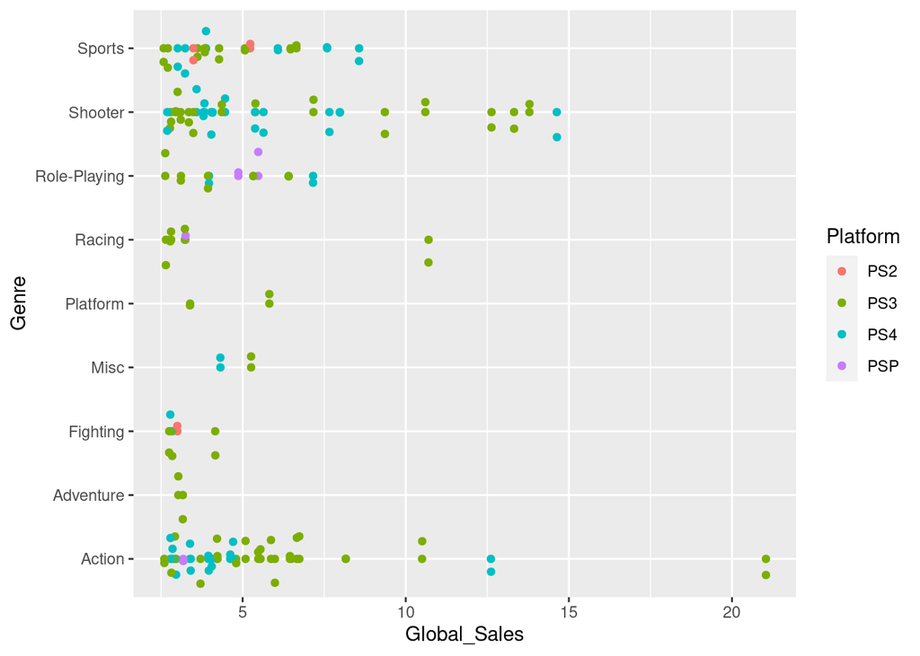

```r
ggplot(ps_games %>% filter(Global_Sales >= 2.58), aes(Global_Sales, Genre, col=Platform)) + geom_point() + geom_jitter()
```

### Top Xbox Genres (Million USD)

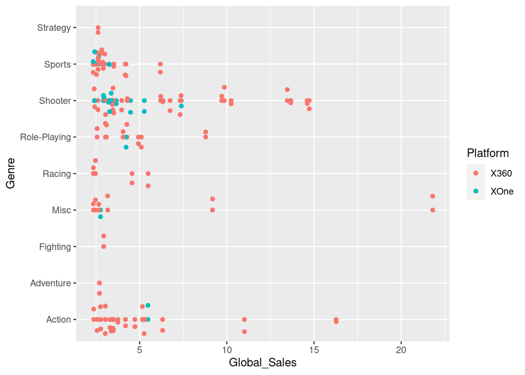

```r
ggplot(xbox_games %>% filter(Global_Sales >= 2.34), aes(Global_Sales, Genre, col=Platform)) + geom_point() + geom_jitter()
```

### Top Nintendo Genres (Million USD)

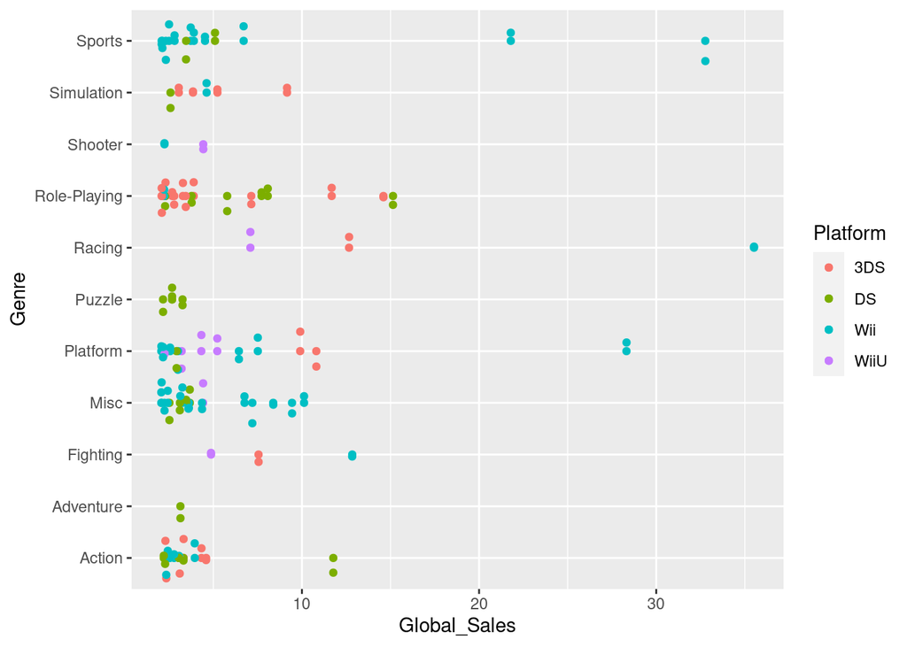

```r
ggplot(nintendo_games %>% filter(Global_Sales >= 2.06), aes(Global_Sales, Genre, col=Platform)) + geom_point() + geom_jitter()
```

## Key Takeaways

As shown in the data visuals, the most popular genres on Playstation were:

- Action
- Shooter
- Sports

On Xbox:

- Action
- Shooter
- Role-Playing
- Sports

On Nintendo:

- Action
- Miscellaneous
- Platform
- Role-Playing

The following table further supports this discovery by displaying the top 50 games across all consoles.

```r
top_console_games <- last_15_years %>% filter(Global_Sales >= 7.38) %>%
  arrange(-Global_Sales)
head(top_console_games)
```

```
##                        Name Platform Year_of_Release    Genre
## 1            Mario Kart Wii      Wii            2008   Racing
## 2         Wii Sports Resort      Wii            2009   Sports
## 3 New Super Mario Bros. Wii      Wii            2009 Platform
## 4        Kinect Adventures!     X360            2010     Misc
## 5              Wii Fit Plus      Wii            2009   Sports
## 6        Grand Theft Auto V      PS3            2013   Action
##                Publisher NA_Sales EU_Sales JP_Sales Other_Sales Global_Sales
## 1               Nintendo    15.68    12.76     3.79        3.29        35.52
## 2               Nintendo    15.61    10.93     3.28        2.95        32.77
## 3               Nintendo    14.44     6.94     4.70        2.24        28.32
## 4 Microsoft Game Studios    15.00     4.89     0.24        1.69        21.81
## 5               Nintendo     9.01     8.49     2.53        1.77        21.79
## 6   Take-Two Interactive     7.02     9.09     0.98        3.96        21.04
##   Critic_Score Critic_Count User_Score User_Count           Developer Rating
## 1           82           73        8.3        709            Nintendo      E
## 2           80           73          8        192            Nintendo      E
## 3           87           80        8.4        594            Nintendo      E
## 4           61           45        6.3        106 Good Science Studio      E
## 5           80           33        7.4         52            Nintendo      E
## 6           97           50        8.2       3994      Rockstar North      M
```

## The Next Step?

- Incorporate past success to future inspirations
- Learn from indie developers to evaluate popularity

My suggestion to these three companies is to take a step back and recall the formulas that allowed earlier games to succeed to begin with as well as utilize indie developers to get a better understanding of new preferences among players.